# R Markdown

Alan T. Arnholt

Sep 12, 2017

## Understanding the data

- Use `summary()` and `str()`
- Use the short cut to insert a code chunk! - `Ctrl + Alt + I`

```r
summary(UCBAdmissions)
```

```
Number of cases in table: 4526
Number of factors: 3
Test for independence of all factors:
    Chisq = 2000.3, df = 16, p-value = 0
```

```r
str(UCBAdmissions)
```

```
 table [1:2, 1:2, 1:6] 512 313 89 19 353 207 17 8 120 205 ...
 - attr(*, "dimnames")=List of 3
  ..$ Admit : chr [1:2] "Admitted" "Rejected"
  ..$ Gender: chr [1:2] "Male" "Female"
  ..$ Dept  : chr [1:6] "A" "B" "C" "D" ...
```

## Wrangle data

### Using `dplyr`

Main verbs:

- Pick observations by their values with `filter()`
- Reorder the rows with `arrange()`
- Pick variables by their name with `select()`
- Create new variables with `mutate()`
- Collapse many values to a single summary with `summarize()`

See the [data transformation cheat sheet](https://github.com/rstudio/cheatsheets/raw/master/source/pdfs/data-transformation-cheatsheet.pdf) for more information.

```r
UCB <- as.data.frame(UCBAdmissions)
UCB
```

```
      Admit Gender Dept Freq
1  Admitted   Male    A  512
2  Rejected   Male    A  313
3  Admitted Female    A   89
4  Rejected Female    A   19
5  Admitted   Male    B  353
6  Rejected   Male    B  207
7  Admitted Female    B   17
8  Rejected Female    B    8
9  Admitted   Male    C  120
10 Rejected   Male    C  205
11 Admitted Female    C  202
12 Rejected Female    C  391
13 Admitted   Male    D  138
14 Rejected   Male    D  279
15 Admitted Female    D  131
16 Rejected Female    D  244
17 Admitted   Male    E   53
18 Rejected   Male    E  138
19 Admitted Female    E   94
20 Rejected Female    E  299
21 Admitted   Male    F   22
22 Rejected   Male    F  351
23 Admitted Female    F   24
24 Rejected Female    F  317
```

```r
# Not quite what we want yet
library(dplyr)
ucb_admit <- UCB %>%
  slice(rep(1:n(), Freq)) %>%
  select(-Freq)
ucb_admit
```

```
# A tibble: 4,526 x 3
      Admit Gender   Dept
     <fctr> <fctr> <fctr>
 1 Admitted   Male      A
 2 Admitted   Male      A
 3 Admitted   Male      A
 4 Admitted   Male      A
 5 Admitted   Male      A
 6 Admitted   Male      A
 7 Admitted   Male      A
 8 Admitted   Male      A
 9 Admitted   Male      A
10 Admitted   Male      A
# ... with 4,516 more rows
```

## A few summary numbers

```r
ucb_admit %>%
  count(Admit, Gender)
```

```
# A tibble: 4 x 3
     Admit Gender     n
    <fctr> <fctr> <int>
1 Admitted   Male  1198
2 Admitted Female   557
3 Rejected   Male  1493
4 Rejected Female  1278
```

Does this look like discrimination? We will display the data using `ggplot2`. First we will need to load the package using `library()`. See the [Data Visualization with `ggplot2` cheat sheet](https://github.com/rstudio/cheatsheets/raw/master/source/pdfs/ggplot2-cheatsheet-2.1.pdf) for more details.

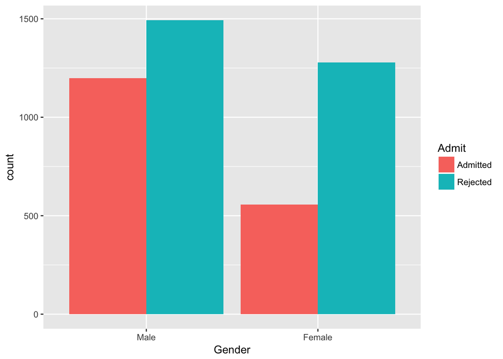

```r
library(ggplot2)
ggplot(data = ucb_admit, aes(x = Gender, fill = Admit)) +
  geom_bar(position = "dodge")
```

What do you think?

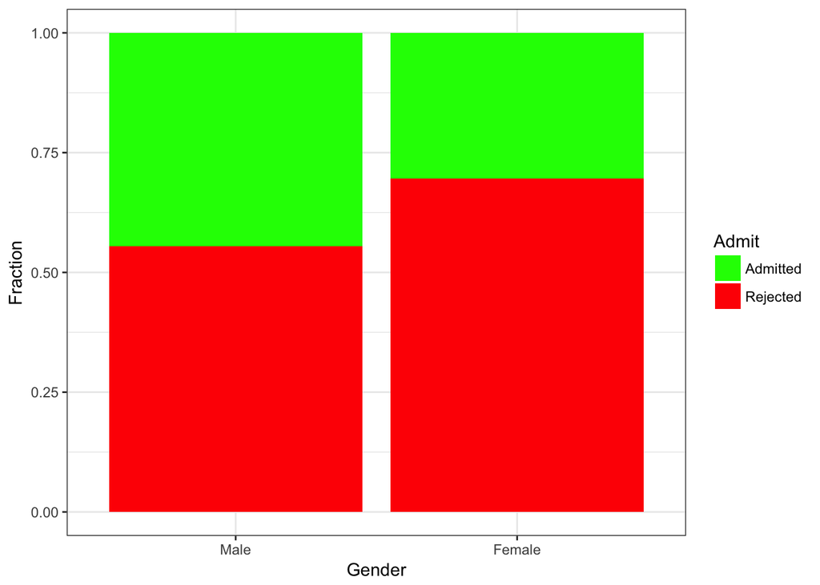

```r
ggplot(data = ucb_admit, aes(x = Gender, fill = Admit)) +
  geom_bar(position = "fill") +
  labs(y = "Fraction") +
  scale_fill_manual(values = c("green", "red")) +
  theme_bw()
```

## Computing the actual numbers

- To insert the pipe operator (`%>%`) use the short cut `Ctrl + Shift + M`

```r
library(tidyr)
ucb_admit %>%
  count(Admit, Gender)
```

```
# A tibble: 4 x 3
     Admit Gender     n
    <fctr> <fctr> <int>
1 Admitted   Male  1198
2 Admitted Female   557
3 Rejected   Male  1493
4 Rejected Female  1278
```

```r
ucb_admit %>%
  count(Admit, Gender) %>%
  spread(Admit, n)
```

```
# A tibble: 2 x 3
  Gender Admitted Rejected
* <fctr>    <int>    <int>
1   Male     1198     1493
2 Female      557     1278
```

```r
ucb_admit %>%
  count(Admit, Gender) %>%
  spread(Admit, n) %>%
  mutate(Percent_Rejected = Rejected / (Admitted + Rejected),
         Percent_Accepted = Admitted /(Admitted + Rejected))
```

```
# A tibble: 2 x 5
  Gender Admitted Rejected Percent_Rejected Percent_Accepted
  <fctr>    <int>    <int>            <dbl>            <dbl>
1   Male     1198     1493        0.5548123        0.4451877
2 Female      557     1278        0.6964578        0.3035422
```

Next we store the `tibble` as the object `basicUCB`.

```r
basicUCB <- ucb_admit %>%
  count(Admit, Gender) %>%
  spread(Admit, n) %>%
  mutate(Percent_Rejected = Rejected / (Admitted + Rejected),
         Percent_Accepted = Admitted /(Admitted + Rejected))
basicUCB
```

```
# A tibble: 2 x 5
  Gender Admitted Rejected Percent_Rejected Percent_Accepted
  <fctr>    <int>    <int>            <dbl>            <dbl>
1   Male     1198     1493        0.5548123        0.4451877
2 Female      557     1278        0.6964578        0.3035422
```

A graph of the percent that were accepted follows.

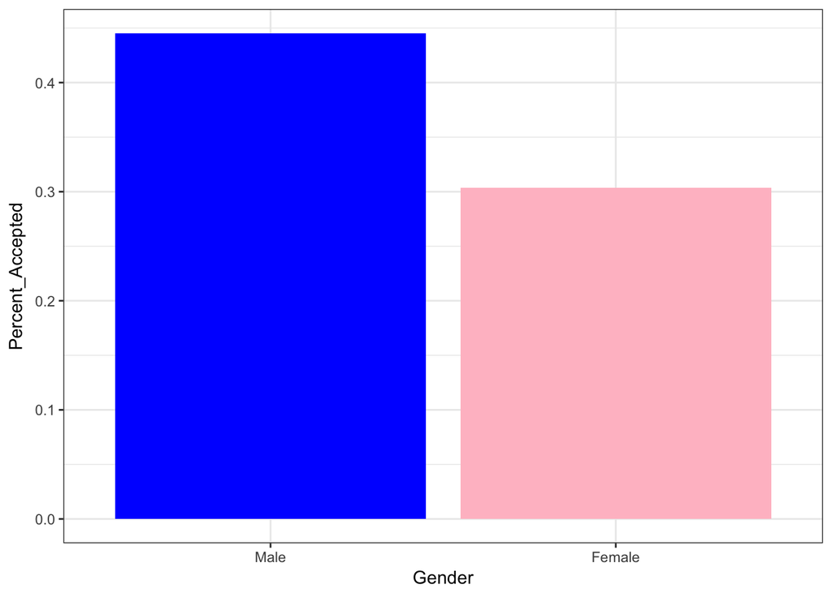

```r
ggplot(data = basicUCB, aes(x = Gender, y = Percent_Accepted)) +
  geom_bar(stat = "identity", fill = c("blue", "pink")) +
  theme_bw()
```

Next, we look at the percentages in each department.

```r
UCBres <- ucb_admit %>%
  group_by(Dept) %>%
  count(Admit, Gender) %>%
  spread(Admit, n) %>%
  mutate(Percent_Accepted = Admitted/(Admitted + Rejected),
         Percent_Rejected = Rejected/(Admitted + Rejected))
UCBres
```

```
# A tibble: 12 x 6
# Groups:   Dept [6]
     Dept Gender Admitted Rejected Percent_Accepted Percent_Rejected
   <fctr> <fctr>    <int>    <int>            <dbl>            <dbl>
 1      A   Male      512      313       0.62060606        0.3793939
 2      A Female       89       19       0.82407407        0.1759259
 3      B   Male      353      207       0.63035714        0.3696429
 4      B Female       17        8       0.68000000        0.3200000
 5      C   Male      120      205       0.36923077        0.6307692
 6      C Female      202      391       0.34064081        0.6593592
 7      D   Male      138      279       0.33093525        0.6690647
 8      D Female      131      244       0.34933333        0.6506667
 9      E   Male       53      138       0.27748691        0.7225131
10      E Female       94      299       0.23918575        0.7608142
11      F   Male       22      351       0.05898123        0.9410188
12      F Female       24      317       0.07038123        0.9296188
```

Graphing the information in `UCBres`.

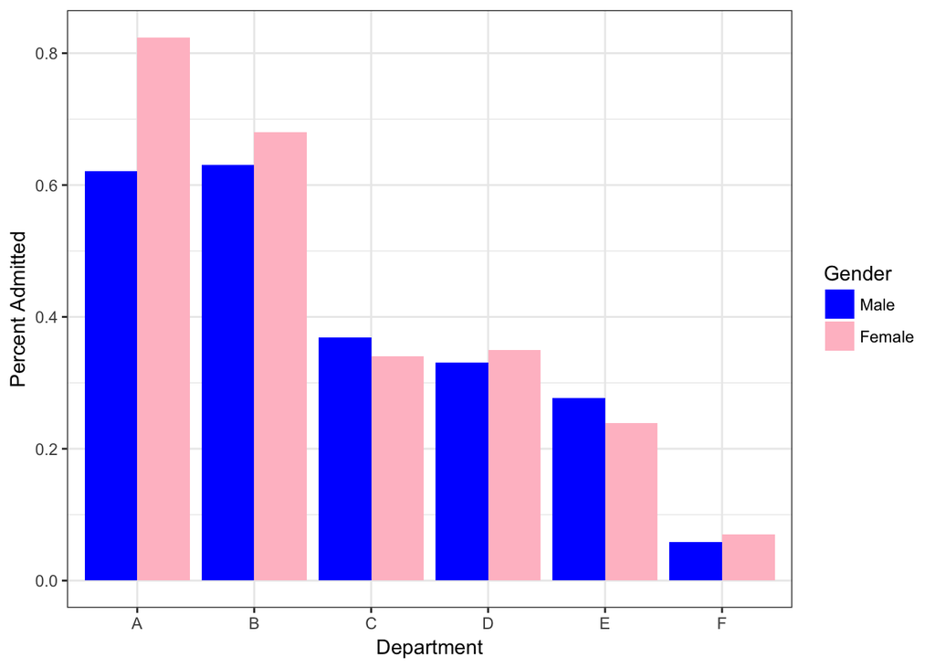

```r
ggplot(data = UCBres, aes(x = Dept, y = Percent_Accepted, fill = Gender)) +
  geom_bar(stat = "identity", position = "dodge") +
  labs(y = "Percent Admitted", x = "Department") +
  theme_bw() +
  scale_fill_manual(values = c("blue", "pink"))
```

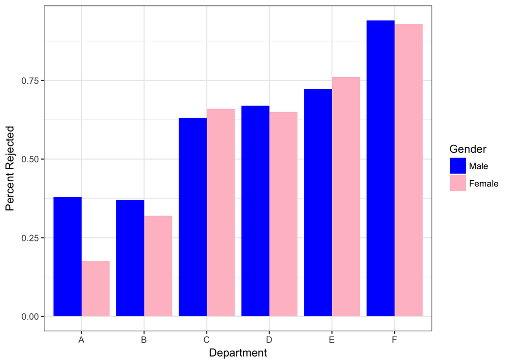

```r
ggplot(data = UCBres, aes(x = Dept, y = Percent_Rejected, fill = Gender)) +
  geom_bar(stat = "identity", position = "dodge") +
  labs(y = "Percent Rejected", x = "Department") +
  theme_bw() +
  scale_fill_manual(values = c("blue", "pink"))
```

## Visualizing Categorical Data

- Use the `vcd` package

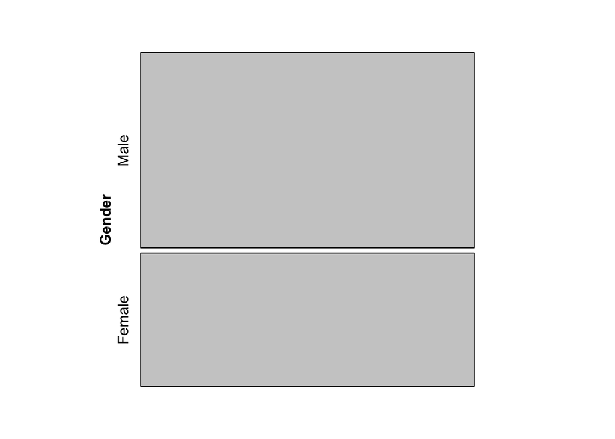

```r
library(vcd)
mosaic(~Gender, data = UCB)
```

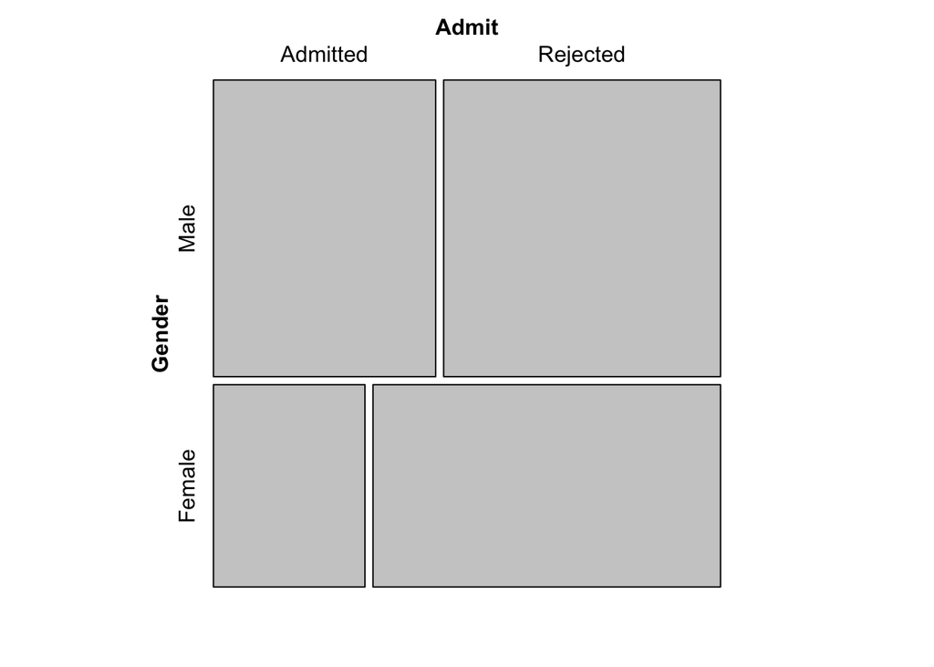

```r
mosaic(~Gender + Admit, data = UCB)
```

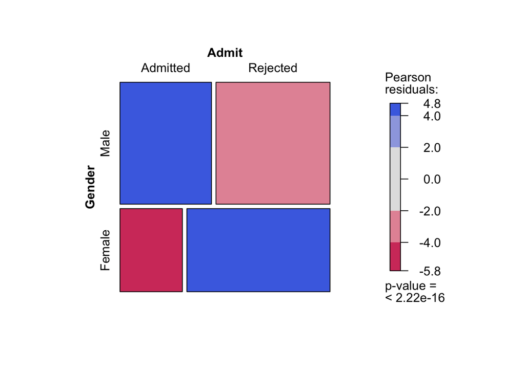

```r
mosaic(~Gender + Admit, data = UCB, shade = TRUE)
```

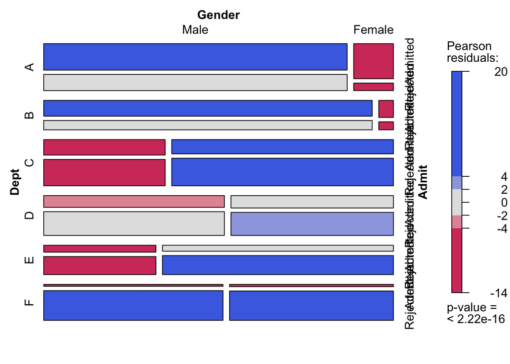

```r
mosaic(~Dept + Gender + Admit, data = UCB, shade = TRUE)
```

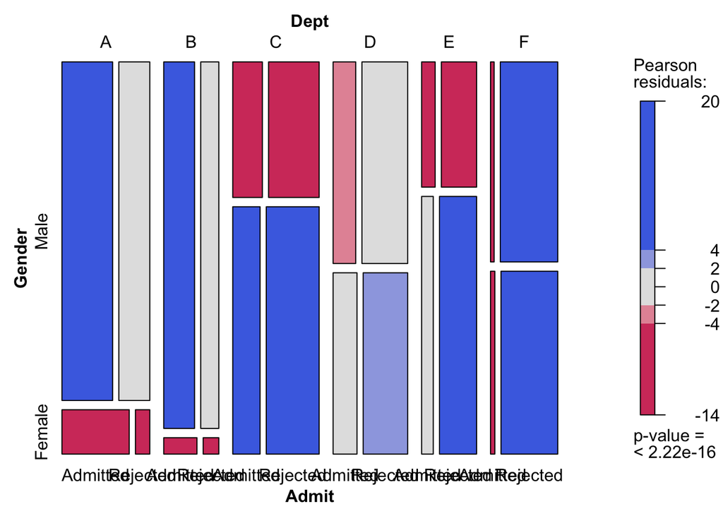

```r
mosaic(~Dept + Gender + Admit, data = UCB, shade = TRUE,
       direction = c("v", "h", "v"))
```

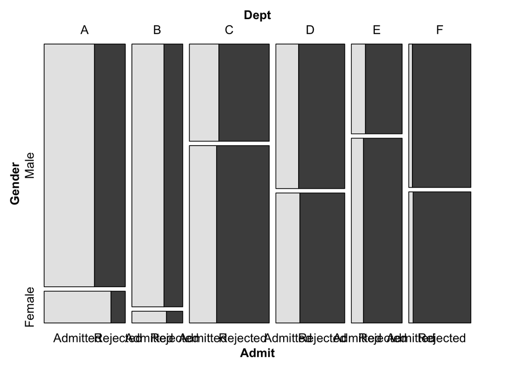

```r
mosaic(~Dept + Gender + Admit, data = UCB, shade = TRUE,
       direction = c("v", "h", "v"), highlighting = "Admit")
```

## Simple Random Samples / Stratified Random Samples

- Remove the District of Columbia from the `county` data frame of the `openintro` package.

```r
library(openintro)
data(county)
str(county)
```

```
'data.frame':   3143 obs. of  10 variables:
 $ name         : Factor w/ 1877 levels "Abbeville County",..: 83 90 101 151 166 227 237 250 298 320 ...
 $ state        : Factor w/ 51 levels "Alabama","Alaska",..: 1 1 1 1 1 1 1 1 1 1 ...
 $ pop2000      : num  43671 140415 29038 20826 51024 ...
 $ pop2010      : num  54571 182265 27457 22915 57322 ...
 $ fed_spend    : num  6.07 6.14 8.75 7.12 5.13 ...
 $ poverty      : num  10.6 12.2 25 12.6 13.4 25.3 25 19.5 20.3 17.6 ...
 $ homeownership: num  77.5 76.7 68 82.9 82 76.9 69 70.7 71.4 77.5 ...
 $ multiunit    : num  7.2 22.6 11.1 6.6 3.7 9.9 13.7 14.3 8.7 4.3 ...
 $ income       : num  24568 26469 15875 19918 21070 ...
 $ med_income   : num  53255 50147 33219 41770 45549 ...
```

```r
summary(county)
```

```
                name           state         pop2000
 Washington County:  30   Texas   : 254   Min.   :     67
 Jefferson County :  25   Georgia : 159   1st Qu.:  11210
 Franklin County  :  24   Virginia: 134   Median :  24608
 Jackson County   :  23   Kentucky: 120   Mean   :  89623
 Lincoln County   :  23   Missouri: 115   3rd Qu.:  61766
 Madison County   :  19   Kansas  : 105   Max.   :9519338
 (Other)          :2999   (Other) :2256   NA's   :3
    pop2010          fed_spend          poverty     homeownership
 Min.   :     82   Min.   :  0.000   Min.   : 0.0   Min.   : 0.00
 1st Qu.:  11104   1st Qu.:  6.964   1st Qu.:11.0   1st Qu.:69.50
 Median :  25857   Median :  8.669   Median :14.7   Median :74.60
 Mean   :  98233   Mean   :  9.991   Mean   :15.5   Mean   :73.26
 3rd Qu.:  66699   3rd Qu.: 10.857   3rd Qu.:19.0   3rd Qu.:78.40
 Max.   :9818605   Max.   :204.616   Max.   :53.5   Max.   :91.30
                   NA's   :4
   multiunit         income        med_income
 Min.   : 0.00   Min.   : 7772   Min.   : 19351
 1st Qu.: 6.10   1st Qu.:19030   1st Qu.: 36952
 Median : 9.70   Median :21773   Median : 42445
 Mean   :12.33   Mean   :22505   Mean   : 44270
 3rd Qu.:15.90   3rd Qu.:24814   3rd Qu.: 49142
 Max.   :98.50   Max.   :64381   Max.   :115574
```

```r
county_noDC <- county %>%
  filter(state != "District of Columbia") %>%
  droplevels()
dim(county_noDC)
```

```
[1] 3142   10
```

- Create a simple random sample of $n = 100$ counties.

```r
set.seed(123)
county_srs <- county_noDC %>%
  sample_n(size = 100)
head(county_srs)
```

```
                    name     state pop2000 pop2010 fed_spend poverty
904      Comanche County    Kansas    1967    1891  9.509783     8.9
2477     Lawrence County Tennessee   39926   41869  9.451766    17.4
1285    Menominee County  Michigan   25326   24029  7.288235    12.2
2772         Wood County     Texas   36752   41964  8.384973    14.0
2952   Williamsburg city  Virginia   11998   14068 23.147285    16.5
143  Independence County  Arkansas   34233   36647  8.234153    19.3
     homeownership multiunit income med_income
904           82.9       6.1  22974      34808
2477          77.9       7.4  18086      34985
1285          81.2       9.2  21624      41332
2772          81.4       4.5  21682      41277
2952          49.5      36.3  22851      50794
143           72.8       7.3  19912      34625
```

- Compute the average for `fed_spend`.

```r
county_srs %>%
  summarize(Average = mean(fed_spend))
```

```
   Average
1 10.42022
```

- How many states are represented in `county_srs`?

```r
county_srs %>%
  summarize(Number = n_distinct(state))
```

```
  Number
1     38
```

- Create a stratified random sample of size $n = 100$ by stratifying on states.

```r
set.seed(321)
county_str <- county_noDC %>%
  group_by(state) %>%
  sample_n(size = 2)
head(county_str)
```

```
# A tibble: 6 x 10
# Groups:   state [3]
                          name   state pop2000 pop2010 fed_spend poverty
                        <fctr>  <fctr>   <dbl>   <dbl>     <dbl>   <dbl>
1            Washington County Alabama   18097   17581  7.829987    19.7
2            Tallapoosa County Alabama   41475   41616  8.643575    17.5
3       Dillingham Census Area  Alaska    4922    4847 11.404168    18.1
4 Fairbanks North Star Borough  Alaska   82840   97581 16.850360     7.6
5              Greenlee County Arizona    8547    8437  7.035558    13.5
6                Graham County Arizona   33489   37220  7.665852    20.0
# ... with 4 more variables: homeownership <dbl>, multiunit <dbl>,
#   income <dbl>, med_income <dbl>
```

- Compute the average for `fed_spend`.

```r
county_str %>%
  summarize(Average = mean(fed_spend))
```

```
# A tibble: 50 x 2
         state   Average
        <fctr>     <dbl>
 1     Alabama  8.236781
 2      Alaska 14.127264
 3     Arizona  7.350705
 4    Arkansas 10.404131
 5  California  9.106758
 6    Colorado  7.093585
 7 Connecticut  9.787831
 8    Delaware  9.574810
 9     Florida  9.876874
10     Georgia  8.239389
# ... with 40 more rows
```

- Not what we want! - Ungroup the table first.

```r
county_str %>%
  ungroup() %>% # return ungrouped copy of table
  summarize(Average = mean(fed_spend, na.rm = TRUE))
```

```
# A tibble: 1 x 1
  Average
    <dbl>
1 9.67646
```